# Wrangling_MASTER_FINAL-READY-CLEANED_5lipca24-Copy1

Project 4. Wrangle and Analyze Data - WeRateDOgs

WeRateDogs is a Twitter (X) account that posts and rates pictures of dogs. Udacity provided the data for the analysis. After wrangling the data, we analysed the following insights:

What are the most popular dog breeds based on the number of posts, interactions by Twitter users (favorite and retweet counts), and ratings?

What is the correlation between Favorite Counts and Retweet Counts?

What are the trends in dog ratings over time?

What are monthly patterns or trends in number of tweets?

What are the most popular dog types in the dataset?

1 INSIGHT What are the most popular dog breeds based on the number of posts, interactions by Twitter users (favorite and retweet counts), and ratings?

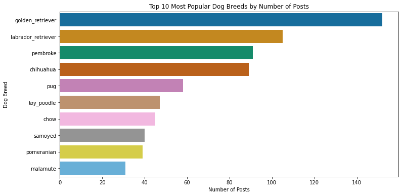

[figure not shown]

[figure not shown]

Conclusions:

Golden Retriever (1st) and Labrador Retriever (2nd) dominate in both the number of posts and total interactions, indicating their overall popularity.

Pembroke and Chihuahua also show significant presence and engagement.

2 INSIGHT What is the correlation between Favorite Counts and Retweet Counts?

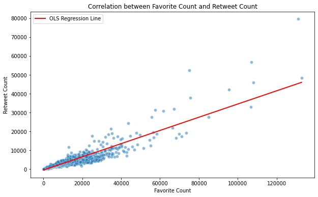

A correlation coefficient of 0.91 indicates a very strong positive linear relationship between favorite counts and retweet counts.

This means that as the number of favorite counts increases, the number of retweet counts also increases proportionally.

Scatter Plot Analysis:

The scatter plot visually confirms the strong positive correlation. The high correlation and the scatter plot together suggest that favorite counts and retweet counts are strongly related. When analyzing tweet popularity or engagement, both metrics are likely to move together, making either a good indicator of the other.

The results of the OLS regression analysis:

The regression model shows a very strong positive relationship between favorite counts and retweet counts.

For each additional favorite, retweets are expected to increase by about 0.35.

The model explains a significant portion of the variability in retweet counts (R-squared = 0.83).

Both the predictor and the overall model are statistically significant.

For the future reference: The regression model can be extended for more insights by including additional predictors: like the time or the dog breed.

3 INSIGHT

What are trends in dog ratings over time?

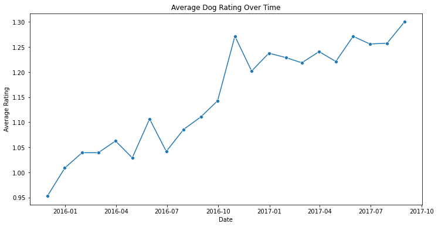

Conclusions:

For the future reference: it might be interesting to investigate this further by building a statistical linear regression model to:

- calculate the linear trend and fit a linear regression model to see if there is a statistically significant upward trend.
- check for seasonality to Look for any periodic patterns within the data.
- calculate moving average to observe underlying trends without short-term fluctuations. For this project, we will not contunue the investigation in this direction.

4 INSIGHT What are the monthly trends in number of tweets?

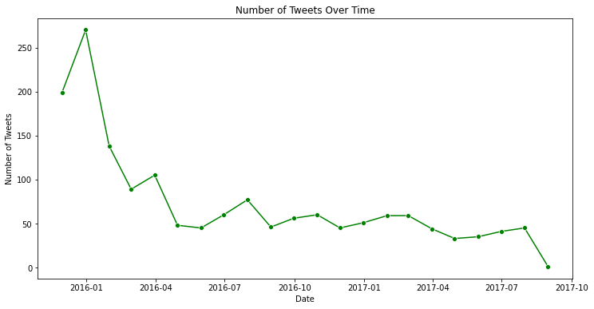

Conclusions:

There was an initial surge in the number of tweets, peaking in early 2016. This could be due to increased popularity or a specific event driving higher engagement.

The sharp decline after the peak indicates that the initial surge was not sustained. This could be due to various factors such as changes in user interest, etc.

The stabilization period indicates a consistent level of activity with around 50 tweets per month. It might be suggesting a loyal user base or stable content production.

The decline towards the end of the period might indicate a drop in engagement or content production.

All these result could be investigated further. For example, we could: 1.Analyze the content and context of tweets during the peak period to understand what drove the high volume of tweets. 2.Look into the content and engagement strategies during the stabilization period to understand what kept the engagement steady. 3.Investigate the factors leading to the decline in tweets towards the end of the period to identify potential areas for improvement or changes in strategy.

However, in this project, we will not investigate it further.

5 INSIGHT: What are the most popular dog types in the dataset?

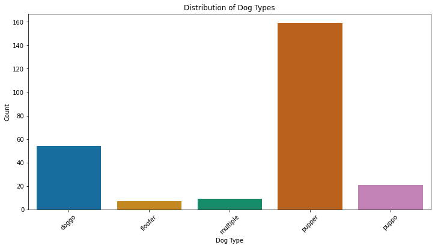

Conclusions:

Dog type 'pupper' (1st) and 'doggo' (2nd) are significantly more common in the dataset, which could indicate either a bias in the data collection or genuine popularity among the Twitter users.